# Homework 3

Zinnia Nie

## Section A: tidyr with obesity and education data

The following chunk reads in and transforms the `obseity-hw.csv` data file (which is **different from the files used in lectures**) to remove children and missing rows, estimate the number of obese individuals of a given sex and age in each zip code, and summarise these numbers over zip and sex. Description of columns:

- `zip` = zip code
- `sex` = sex (male or female)
- `adult_n` = estimated # of adults (by zip and sex)
- `obese_n` = estimated # of obese adults (by zip and sex)
- `obese_p` = estimated proportion of obese adults (by zip and sex)

```r
obesity = read_csv("../../data/obesity-hw.csv") %>%
  drop_na() %>%                         ## drop rows with missing data
  filter(age != "05-17") %>%            ## drop children
  mutate(obese_n = pop*obese/bmi) %>%   ## add estimated # of obese adults
  group_by(zip,sex) %>%                 ## aggregate over age and sex
  summarize(adult_n = sum(pop),         ## compute estimates
            obese_n = sum(obese_n),
            obese_p = obese_n/adult_n) %>%
  ungroup()

head(obesity,10)
```

```
## # A tibble: 10 × 5
##      zip sex    adult_n obese_n obese_p
##    <dbl> <chr>    <dbl>   <dbl>   <dbl>
##  1 53001 female     671   259.    0.386
##  2 53001 male       682   330.    0.483
##  3 53002 female     977   369.    0.377
##  4 53002 male      1052   404.    0.384
##  5 53004 female    1244   553.    0.445
##  6 53004 male      1164   604.    0.519
##  7 53005 female    8039  2153.    0.268
##  8 53005 male      7150  2479.    0.347
##  9 53006 female     263    92.4   0.351
## 10 53006 male       195    75     0.385
```

The next chunk reads in the `education.csv` file. Description of columns:

- `pct_m_bach` = % male adults (aged 25+, of the given sex by zip) with at least a bachelors degree
- `pct_f_bach` = % female adults (aged 25+, of the given sex by zip) with at least a bachelors degree

```r
education = read_csv("../../data/education.csv")
```

### 1

Then, join the `obesity` and pivoted `education` data frames together by zip and sex so that **only rows they *both* have in common are kept** (hint: if you ensure the two data frames have the same column names for zip and sex and the same value names (i.e. “male” and “female” in both) then this should happen automagically).

Print out the first ten rows of this final resulting data frame by piping it into `%>% head(10)`.

```r
# insert code below
editted <- education %>% rename(male=pct_m_bach, female=pct_f_bach) %>%
  pivot_longer(cols=!zip, names_to = "sex", values_to = "bach_p")

editted %>% head(10)
```

```
## # A tibble: 10 × 3
##      zip sex    bach_p
##    <dbl> <chr>   <dbl>
##  1 53001 male     13
##  2 53001 female   23
##  3 53002 male     16.2
##  4 53002 female   25.4
##  5 53003 male      6.8
##  6 53003 female    9.4
##  7 53004 male     23.3
##  8 53004 female   26.8
##  9 53005 male     55.6
## 10 53005 female   53.9
```

```r
joined <- inner_join(obesity, editted, by=c("zip", "sex"))

joined %>% head(10)
```

```
## # A tibble: 10 × 6
##      zip sex    adult_n obese_n obese_p bach_p
##    <dbl> <chr>    <dbl>   <dbl>   <dbl>  <dbl>
##  1 53001 female     671   259.    0.386   23
##  2 53001 male       682   330.    0.483   13
##  3 53002 female     977   369.    0.377   25.4
##  4 53002 male      1052   404.    0.384   16.2
##  5 53004 female    1244   553.    0.445   26.8
##  6 53004 male      1164   604.    0.519   23.3
##  7 53005 female    8039  2153.    0.268   53.9
##  8 53005 male      7150  2479.    0.347   55.6
##  9 53006 female     263    92.4   0.351   26.8
## 10 53006 male       195    75     0.385   15.4
```

### 2

Next we will investigate connections between obesity and education status (in terms of a bachelors degree or no bachelors degree) by sex. Start by estimating the following quantities: - Proportions of Wisconsin people with a bachelors degree in each sex who ARE obese (note this implies the denominator of the ratio is the total number of people in each zip and sex *with* a bachelors degree) - Proportions of Wisconsin people without a bachelors degree in each sex who ARE obese (note this implies the denominator of the ratio is the total number of people in each zip and sex *without* a bachelors degree)

- Print out these values in a table with two rows - one for male and one for female, and three columns - one for sex, and one for each of the two estimated percentages noted above.
- State any assumptions you need to make when carrying out these calculations. (Recall that you need to sum up totals of people before finding proportions.)

(Hint: First, use `mutate()` to find in each zip and sex the estimated number of bachelors and non-bachelors. Then, estimate for each zip and sex the number of obese people with a bachelors degree by multiplying the number of bachelors with the rate of obesity (note this assumes these are independent, which is an assumption we have to make here). Repeat this step but for the people without a bachelors degree. Now, divide the number of obese people with a bachelors degree by the number of people with a bachelors degree to get the first proportion. Repeat this step for the people without a bachelors degree.

Then, summarise across your dataset to estimate **for each sex, across all zips**, the total number of obese people with a bachelors degree, the total number of obese people without a bachelors degree, the total number of people with a bachelors degree, and the total number of people without a bachelors degree. Use these to produce these final quantities:

- the estimated proportion of people with a bachelor degree who are obese (for EACH sex)
- the estimated proportion of people without a bachelor degree who are obese (for EACH sex)

Show these two final proportions. What do you observe?

```r
# insert code below
connection <- joined %>% mutate(non_bach_p = 100-bach_p) %>%
  mutate(bach_n = adult_n*(bach_p/100), non_bach_n = adult_n*(non_bach_p/100)) %>%
  mutate(obese_bach_n = bach_n*obese_p, obese_non_bach_n = non_bach_n*obese_p)

connection %>% group_by(sex) %>% summarise(obese_bach_prop = sum(obese_bach_n)/sum(bach_n), obese_non_bach_prop = sum(obese_non_bach_n)/sum(non_bach_n))
```

```
## # A tibble: 2 × 3
##   sex    obese_bach_prop obese_non_bach_prop
##   <chr>            <dbl>               <dbl>
## 1 female           0.371               0.417
## 2 male             0.392               0.434
```

Assumptions: The estimates for population of each zip code and number of obese individuals in each zip code are accurate. Obesity and level of education are independent from each other.

The percent of obese adults is higher for males in both the “has a bachelor degree” and “doesn’t have a bachelor degree” categories by about 2%. Also the obesity rate for people with a bachelor degree is lower than that for those without a bachelor degree for both sexes.

### 3

Make a scatter plot that displays the *percentage* of a zip code aged 25+ with a bachelor’s degree on the x-axis and the *percentage* obese on the y axis. - Use different colors for each sex and add a trend line or curve for each sex. - Create appropriate labels and titles for the plot. - Comment on any apparent patterns in the data.

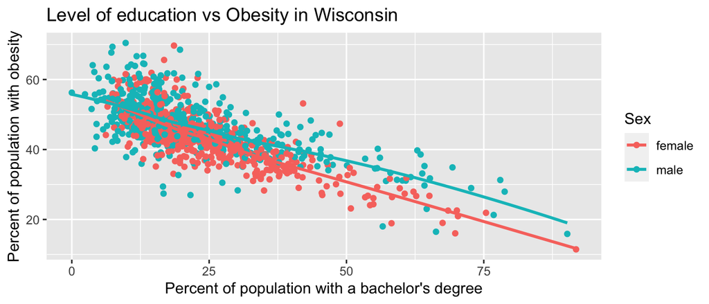

```r
# insert code below
ggplot(data = connection, mapping = aes(x=bach_p, y=obese_p*100, group=sex)) +
  geom_point(aes(color=sex)) +
  geom_smooth(aes(group=sex, color=sex), se=FALSE) +
  xlab("Percent of population with a bachelor's degree") +
  ylab("Percent of population with obesity") +
  labs(color="Sex") +
  ggtitle("Level of education vs Obesity in Wisconsin")
```

There is a negative trend between percent with a bachelor degree and percent of obesity. The more people with bachelor’s degrees, the less people who are obese in that zip code. Also the trend lines by sex shows that as the percent of the population with a bachelor’s degree increases, there are more obese males than females, meaning the rate of obesity decreases with education less for males than for females.

## Section B: stringr with exoplanets dataset

The following block of code will read in the exoplanet data from the file *exoplanets-3sept2020.csv* (same dataset as lecture but a slightly different version), filter to include only confirmed exoplanets, select and rename a subset of variables, and add an index with the row number.

```r
planets = read_csv("../../data/exoplanets-3sept2020.csv")%>%
  filter(default_flag == 1) %>%
  select(pl_name, hostname, discoverymethod, disc_year, disc_facility,
         sy_pnum, pl_rade, pl_bmasse, rowupdate) %>%
  rename(planet=pl_name, star=hostname, method=discoverymethod,
         facility=disc_facility, year=disc_year, number=sy_pnum,
         radius=pl_rade, mass=pl_bmasse, update=rowupdate) %>%
  mutate(index = row_number()) %>%
  select(index, everything())
```

### 4

Create and print a table which shows the number of exoplanets discovered that have the word “Kepler” as part of the planet name, grouped by `year` and `facility`.

What year was the first of these exoplanets discovered by a facility *other than* the Kepler facility?

```r
# insert code below
kepler <- planets %>% filter(str_detect(planet, "Kepler")) %>% group_by(year, facility) %>% arrange(year)

kepler
```

```
## # A tibble: 2,369 × 10
## # Groups:   year, facility [22]
##    index planet      star      method   year facility number radius  mass update
##    <int> <chr>       <chr>     <chr>   <dbl> <chr>     <dbl>  <dbl> <dbl> <chr>
##  1  3013 Kepler-4 b  Kepler-4  Transit  2009 Kepler        1   4.00  24.5 5/14/…
##  2  3168 Kepler-5 b  Kepler-5  Transit  2009 Kepler        1  16.0  671.  10/7/…
##  3  3305 Kepler-6 b  Kepler-6  Transit  2009 Kepler        1  14.6  212.  10/7/…
##  4  3436 Kepler-7 b  Kepler-7  Transit  2009 Kepler        1  18.2  140.  10/7/…
##  5  1591 Kepler-11 b Kepler-11 Transit  2010 Kepler        6   1.8    1.9 5/14/…
##  6  1592 Kepler-11 c Kepler-11 Transit  2010 Kepler        6   2.87   2.9 5/14/…
##  7  1593 Kepler-11 d Kepler-11 Transit  2010 Kepler        6   3.12   7.3 5/14/…
##  8  1594 Kepler-11 e Kepler-11 Transit  2010 Kepler        6   4.19   8   5/14/…
##  9  1595 Kepler-11 f Kepler-11 Transit  2010 Kepler        6   2.49   2   5/14/…
## 10  1596 Kepler-11 g Kepler-11 Transit  2010 Kepler        6   3.33  25   5/14/…
## # ℹ 2,359 more rows
```

```r
kepler %>% filter(!str_detect(facility, "Kepler")) %>% head(1)
```

```
## # A tibble: 1 × 10
## # Groups:   year, facility [1]
##   index planet      star      method    year facility number radius  mass update
##   <int> <chr>       <chr>     <chr>    <dbl> <chr>     <dbl>  <dbl> <dbl> <chr>
## 1  3413 Kepler-68 d Kepler-68 Radial …  2013 W. M. K…      3     NA  245. 6/7/1…
```

The first time a “Kepler” named planed was discovered by a facility other than “Kepler” was in **2013** by the **“W. M. Keck Observatory”**. It was planet “Kepler-68 d”.

### 5

The column `update` in the exoplanet data set has character values where some entries have a date only, such as `5/14/14` and others have a date and time, such as `9/4/18 16:14`.

Create a new column named `update_format` with the value “date” if the format is like `5/14/14`, “datetime” if the format is like `9/4/18 16:14`, and “other” if it is something else.

Print out a summary table that counts the number of observations have each type of `update_format`.

```r
# insert code below
summary <- planets %>% mutate(update_format = ifelse(str_detect(update, "[:digit:]+/[:digit:]+/[:digit:]+[:space:][:digit:]+:[:digit:]+"), "datetime", "date")) %>%
  count(update_format)

summary
```

```
## # A tibble: 2 × 2
##   update_format     n
##   <chr>         <int>
## 1 date           1376
## 2 datetime       2900
```

There are **1376** date only entries and **2900** datetime entries.

### 6

How many *distinct* star names begin with a number?

```r
# insert code below
planets %>% group_by(star) %>% filter(str_starts(star, "[:digit:]")) %>%
  summarise(total = length(star)) %>% summarise(sum = length(star))
```

```
## # A tibble: 1 × 1
##     sum
##   <int>
## 1    32
```

There are **32** distinct star names that begin with a number.

### 7 (Optional, ungraded)

Of the distinct star names that begin with a number, create a bar plot of these leading numbers. The height of the bars should indicate the number of stars for each leading number.

- Display the bars in numerical order (lowest number to the left of the plot window), and include a tick mark and label (indicating the leading number) for each bar.
- Be sure to include descriptive axis labels and a title.

*Hint: First create a variable with the leading number from the star names, then create the bar plot. Be careful because some numbers have more than one digit.*

- What are the name of the stars that have the most common leading number? Print out a table with these star names.

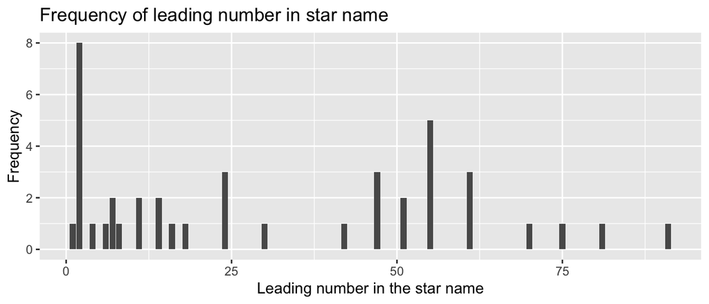

```r
# insert code below
num_starts <- planets %>% filter(str_starts(star, "[:digit:]")) %>% mutate(number = parse_number(star)) %>%
  group_by(number) %>%
  summarise(num = n())


ggplot(data = num_starts, mapping=aes(x=number, y=num)) +
  geom_col() +
  xlab("Leading number in the star name") +
  ylab("Frequency") +
  ggtitle("Frequency of leading number in star name")
```

The most common leading number is **2**.

```r
planets %>% filter(str_starts(star, "[:digit:]")) %>% filter(parse_number(star) == "2")
```

```
## # A tibble: 8 × 10
##   index planet            star  method  year facility number radius  mass update
##   <int> <chr>             <chr> <chr>  <dbl> <chr>     <dbl>  <dbl> <dbl> <chr>
## 1    11 2MASS J01033563-… 2MAS… Imagi…  2013 Paranal…      1   NA   4132. 8/26/…
## 2    12 2MASS J01225093-… 2MAS… Imagi…  2013 W. M. K…      1   NA   7786. 5/14/…
## 3    13 2MASS J02192210-… 2MAS… Imagi…  2015 Cerro T…      1   16.1 4418. 5/14/…
## 4    14 2MASS J04414489+… 2MAS… Imagi…  2010 Hubble …      1   NA   2384. 5/14/…
## 5    15 2MASS J12073346-… 2MAS… Imagi…  2004 Paranal…      1   NA   1271  5/14/…
## 6    16 2MASS J19383260+… 2MAS… Eclip…  2015 Kepler        1   NA    604. 6/4/15
## 7    17 2MASS J21402931+… 2MAS… Imagi…  2009 W. M. K…      1   10.3 6657. 5/14/…
## 8    18 2MASS J22362452+… 2MAS… Imagi…  2016 W. M. K…      1   NA   3973. 11/9/…
```

### 8 (Optional, ungraded)

The convention for naming planets is typically to take the name of the star and then add to the end a space and then a lower-case letter (e.g., b, c). However, not all planet names follow this convention.

How many planet names do not follow this convention?

(Hint: special care is required if the name of the star contains a symbol with special meaning in a regular expression, such as `+`. The easiest way to get around this is to use the `fixed()` function as shown in lecture. Alternatively, you can also add backslashes to escape the special characters in star names (if using this approach, you might want to create a column of escaped patterns before using `str_detect()` to filter planets.)

```r
# insert code below
```